# Forecasting Weekly Sales for Walmart

Daniel Garcia, Nicole Pham

2022-12-05

#######———– Libraries/data importing/cleaning/exploring —————-###### #####################################################################################

### Libraries

```r
# importing libraries
library(tidyverse)
library(skimr)
library(lubridate)
library(MASS)
library(rcompanion)
library(tidymodels)
```

[output not shown]

### Data importing/cleaning/exploring

```r
# importing data set
Walmart= read_csv("C:\\Users\\dgray\\OneDrive\\Stats\\Stat 471 R programming\\R projects\\Walmart.csv")
#Walmart= read_csv("/Users/nicolepham/Documents/STAT/STAT 471/Walmart.csv", show_col_types = FALSE)
glimpse(Walmart)
```

```
## Rows: 6,435
## Columns: 8
## $ Store        <dbl> 1, 1, 1, 1, 1, 1, 1, 1, 1, 1, 1, 1, 1, 1, 1, 1, 1, 1, 1, …
## $ Date         <chr> "05-02-2010", "12-02-2010", "19-02-2010", "26-02-2010", "…
## $ Weekly_Sales <dbl> 1643691, 1641957, 1611968, 1409728, 1554807, 1439542, 147…
## $ Holiday_Flag <dbl> 0, 1, 0, 0, 0, 0, 0, 0, 0, 0, 0, 0, 0, 0, 0, 0, 0, 0, 0, …
## $ Temperature  <dbl> 42.31, 38.51, 39.93, 46.63, 46.50, 57.79, 54.58, 51.45, 6…
## $ Fuel_Price   <dbl> 2.572, 2.548, 2.514, 2.561, 2.625, 2.667, 2.720, 2.732, 2…
## $ CPI          <dbl> 211.0964, 211.2422, 211.2891, 211.3196, 211.3501, 211.380…
## $ Unemployment <dbl> 8.106, 8.106, 8.106, 8.106, 8.106, 8.106, 8.106, 8.106, 7…
```

```r
# changing Date variable to date data structure
# format= year/Month/Day

Walmart<-Walmart %>%
  mutate(Date=dmy(Date))
glimpse(Walmart)
```

```
## Rows: 6,435
## Columns: 8
## $ Store        <dbl> 1, 1, 1, 1, 1, 1, 1, 1, 1, 1, 1, 1, 1, 1, 1, 1, 1, 1, 1, …
## $ Date         <date> 2010-02-05, 2010-02-12, 2010-02-19, 2010-02-26, 2010-03-…
## $ Weekly_Sales <dbl> 1643691, 1641957, 1611968, 1409728, 1554807, 1439542, 147…
## $ Holiday_Flag <dbl> 0, 1, 0, 0, 0, 0, 0, 0, 0, 0, 0, 0, 0, 0, 0, 0, 0, 0, 0, …
## $ Temperature  <dbl> 42.31, 38.51, 39.93, 46.63, 46.50, 57.79, 54.58, 51.45, 6…
## $ Fuel_Price   <dbl> 2.572, 2.548, 2.514, 2.561, 2.625, 2.667, 2.720, 2.732, 2…
## $ CPI          <dbl> 211.0964, 211.2422, 211.2891, 211.3196, 211.3501, 211.380…
## $ Unemployment <dbl> 8.106, 8.106, 8.106, 8.106, 8.106, 8.106, 8.106, 8.106, 7…
```

```r
range(Walmart$Date)
```

```
## [1] "2010-02-05" "2012-10-26"
```

```r
Walmart %>%
  dplyr::select(Weekly_Sales, Temperature, Fuel_Price, CPI, Unemployment) %>%
  skim()
```

Data summary

| Name | Piped data |
| --- | --- |
| Number of rows | 6435 |
| Number of columns | 5 |
| _______________________ |  |
| Column type frequency: |  |
| numeric | 5 |
| ________________________ |  |
| Group variables | None |

**Variable type: numeric**

| skim_variable | n_missing | complete_rate | mean | sd | p0 | p25 | p50 | p75 | p100 | hist |
| --- | --- | --- | --- | --- | --- | --- | --- | --- | --- | --- |
| Weekly_Sales | 0 | 1 | 1046964.88 | 564366.62 | 209986.25 | 553350.10 | 960746.04 | 1420158.66 | 3818686.45 | ▇▆▂▁▁ |
| Temperature | 0 | 1 | 60.66 | 18.44 | -2.06 | 47.46 | 62.67 | 74.94 | 100.14 | ▁▃▆▇▃ |
| Fuel_Price | 0 | 1 | 3.36 | 0.46 | 2.47 | 2.93 | 3.44 | 3.73 | 4.47 | ▆▆▇▇▁ |
| CPI | 0 | 1 | 171.58 | 39.36 | 126.06 | 131.74 | 182.62 | 212.74 | 227.23 | ▇▁▁▂▆ |
| Unemployment | 0 | 1 | 8.00 | 1.88 | 3.88 | 6.89 | 7.87 | 8.62 | 14.31 | ▂▇▆▁▁ |

#———————————– EDA —————————————–# ###################################################################################

#### 1) Weekly Sales

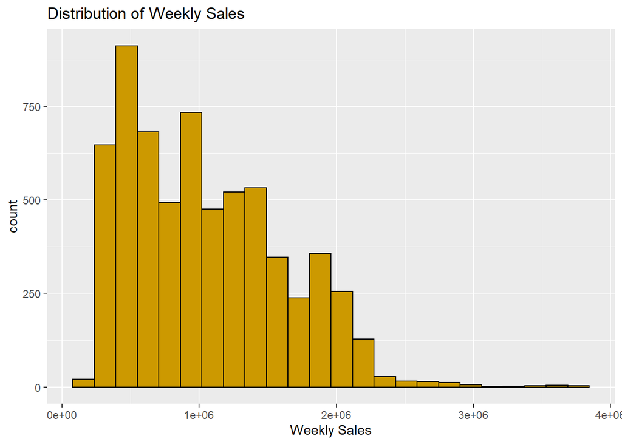

```r
ggplot(Walmart, aes(x=Weekly_Sales)) +
  geom_histogram(bins=24, fill="#CC9900", color="black") +
  labs(title="Distribution of Weekly Sales", x="Weekly Sales")
```

```r
shapiro.test(head(Walmart$Weekly_Sales, 500))
```

```
##
##  Shapiro-Wilk normality test
##
## data:  head(Walmart$Weekly_Sales, 500)
## W = 0.84036, p-value < 2.2e-16
```

Distribution is not normally distributed by Shapiro Test.

```r
mean(Walmart$Weekly_Sales)
```

```
## [1] 1046965
```

```r
median(Walmart$Weekly_Sales)
```

```
## [1] 960746
```

Many outliers, but mean/median is around $1,000,000 in weekly Sales. Median is a better average here, given the outliers.

Mean: $1,046,965 Median: $960,746

#### 2) Weeks with Holidays

```r
# using filter function to see which weeks are holiday weeks
holiday_flag = Walmart %>%
  dplyr::filter(Holiday_Flag==1)
n_unique(holiday_flag$Date)
```

```
## [1] 10
```

```r
holiday_flag
```

```
## # A tibble: 450 × 8
##    Store Date       Weekly_Sales Holiday_Flag Temperature Fuel_P…¹   CPI Unemp…²
##    <dbl> <date>            <dbl>        <dbl>       <dbl>    <dbl> <dbl>   <dbl>
##  1     1 2010-02-12     1641957.            1        38.5     2.55  211.    8.11
##  2     1 2010-09-10     1507461.            1        78.7     2.56  211.    7.79
##  3     1 2010-11-26     1955624.            1        64.5     2.74  212.    7.84
##  4     1 2010-12-31     1367320.            1        48.4     2.94  211.    7.84
##  5     1 2011-02-11     1649615.            1        36.4     3.02  213.    7.74
##  6     1 2011-09-09     1540471.            1        76       3.55  216.    7.96
##  7     1 2011-11-25     2033321.            1        60.1     3.24  218.    7.87
##  8     1 2011-12-30     1497463.            1        44.6     3.13  220.    7.87
##  9     1 2012-02-10     1802477.            1        48.0     3.41  220.    7.35
## 10     1 2012-09-07     1661767.            1        84.0     3.73  222.    6.91
## # … with 440 more rows, and abbreviated variable names ¹Fuel_Price,
## #   ²Unemployment
```

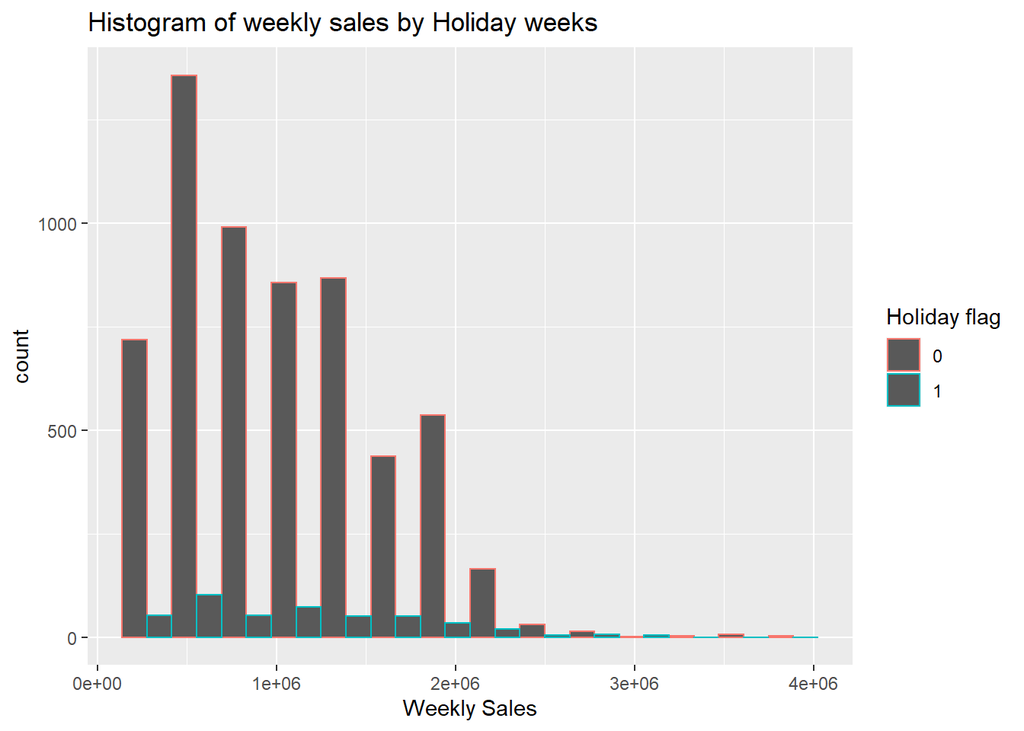

```r
ggplot(Walmart, mapping=aes(x=Weekly_Sales, color=factor(Holiday_Flag))) +
  geom_histogram(position="dodge", bins=14) +
  labs(title="Histogram of weekly sales by Holiday weeks", x="Weekly Sales", color="Holiday flag")
```

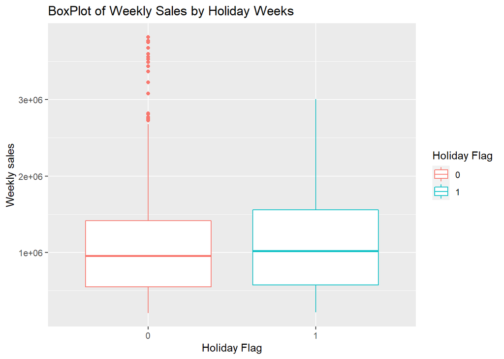

```r
ggplot(Walmart, aes(x=as_factor(Holiday_Flag), y=Weekly_Sales, color=factor(Holiday_Flag)))+
  geom_boxplot() +
  labs(title = 'BoxPlot of Weekly Sales by Holiday Weeks', y='Weekly sales', x='Holiday Flag', color="Holiday Flag")
```

slight increase in median sales for holiday weeks. Outliers in non-holiday weeks.

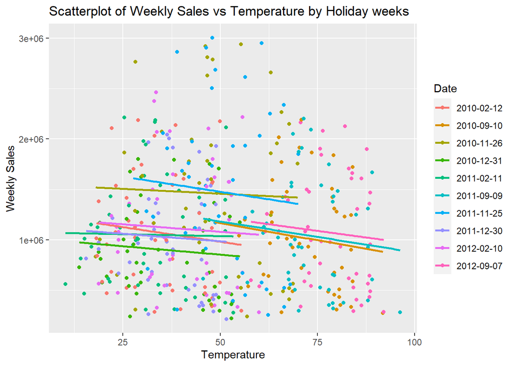

```r
ggplot(data=holiday_flag, mapping=aes(x=Temperature,y=Weekly_Sales, color=factor(Date))) +
  geom_point() +
  geom_smooth(method=lm, formula=y~x, se=FALSE) +
  labs(title="Scatterplot of Weekly Sales vs Temperature by Holiday weeks", y="Weekly Sales", color="Date")
```

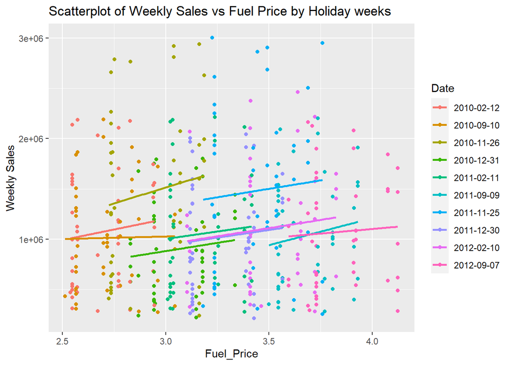

```r
ggplot(data=holiday_flag, mapping=aes(x=Fuel_Price,y=Weekly_Sales, color=factor(Date))) +
  geom_point() +
  geom_smooth(method=lm, formula=y~x, se=F) +
  labs(title="Scatterplot of Weekly Sales vs Fuel Price by Holiday weeks", y="Weekly Sales", color="Date")
```

#### 3) By Store

```r
# checking number of stores
unique(Walmart$Store)
```

```
##  [1]  1  2  3  4  5  6  7  8  9 10 11 12 13 14 15 16 17 18 19 20 21 22 23 24 25
## [26] 26 27 28 29 30 31 32 33 34 35 36 37 38 39 40 41 42 43 44 45
```

```r
# setting store number as factor
Walmart$Store = as.factor(Walmart$Store)
class(Walmart$Store)
```

```
## [1] "factor"
```

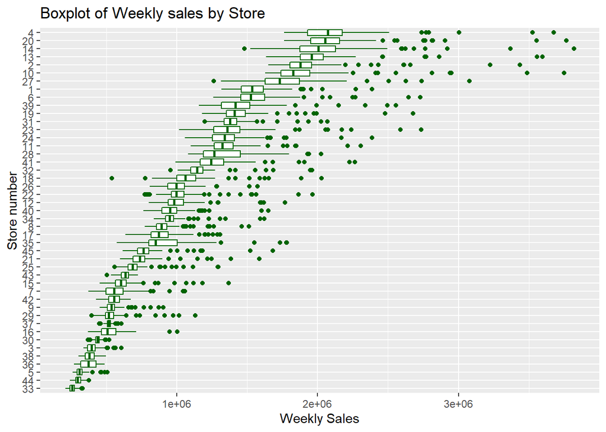

```r
# boxplot of weekly sales by Store
  ggplot(Walmart, aes(Weekly_Sales, reorder(Store,
                                   FUN = median, Weekly_Sales))) +
  geom_boxplot(color="Dark green") +
  labs(title="Boxplot of Weekly sales by Store", x="Weekly Sales", y="Store number")
```

Store 4 has the highest median weekly sales. store 33 has the lowest. Store 28 looks like it has the highest variability, given the extent of the box length.

#### 4) Weekly Sales By Consumer Price Index

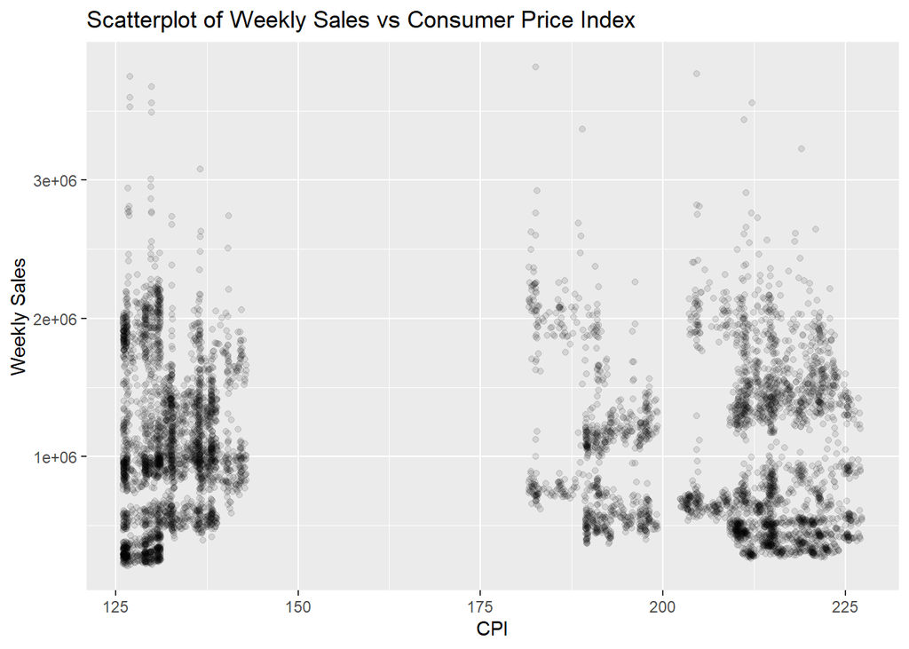

```r
ggplot(Walmart, aes(x=CPI, y=Weekly_Sales)) +
  geom_point(alpha=.1) +
  labs(title="Scatterplot of Weekly Sales vs Consumer Price Index", y="Weekly Sales")
```

appears that CPI doesnt effect weekly sales, since weekly sales seem equally distributed across all CPI ranges

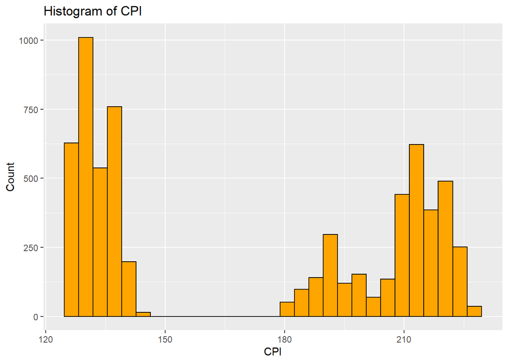

```r
ggplot(Walmart, aes(x=CPI)) +
  geom_histogram(bins=29, fill="orange", color="black") +
  labs(title = 'Histogram of CPI', y='Count', x='CPI')
```

most populated CPI ranges: 125-150, 180-225

#### 5) Unemployment

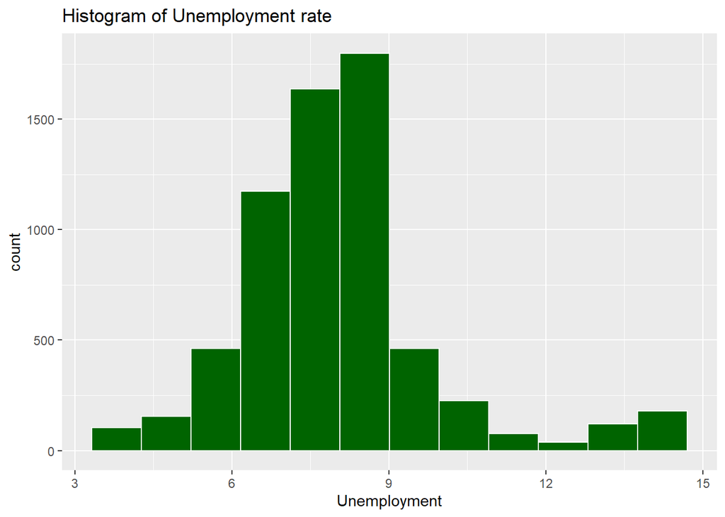

```r
ggplot(Walmart, mapping=aes(x=Unemployment)) +
  geom_histogram(bins=12, fill="dark green", color="white") +
  labs(title="Histogram of Unemployment rate", )
```

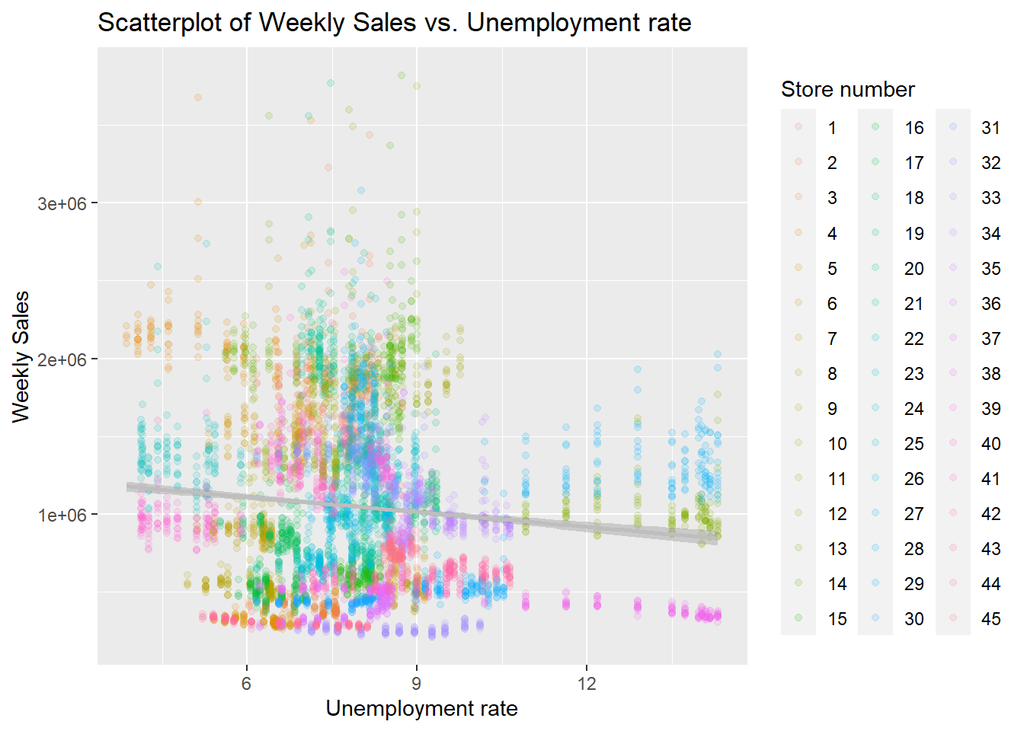

```r
ggplot(Walmart, mapping=aes(x=Unemployment, y=Weekly_Sales, reorder(Store,
                                   FUN = median, Weekly_Sales), color=Store)) +
  geom_point(alpha=.15) +
  geom_smooth(method=lm, formula= y~x, color="grey") +
  labs(title="Scatterplot of Weekly Sales vs. Unemployment rate", x="Unemployment rate", y="Weekly Sales", color="Store number")
```

#### Time

```r
# grouping by date and finding mean of all 45 walmart stores per week// also outputting if the week is a holiday week
Mean_wkly_sales= Walmart %>%
  group_by(Date, Holiday_Flag) %>%
  summarise(Weekly_Sales = mean(Weekly_Sales, na.rm=TRUE))
Mean_wkly_sales
```

```
## # A tibble: 143 × 3
## # Groups:   Date [143]
##    Date       Holiday_Flag Weekly_Sales
##    <date>            <dbl>        <dbl>
##  1 2010-02-05            0     1105572.
##  2 2010-02-12            1     1074148.
##  3 2010-02-19            0     1072822.
##  4 2010-02-26            0      977079.
##  5 2010-03-05            0     1041588.
##  6 2010-03-12            0     1020564.
##  7 2010-03-19            0      999755.
##  8 2010-03-26            0      980755.
##  9 2010-04-02            0     1120530.
## 10 2010-04-09            0     1052562.
## # … with 133 more rows
```

[figure not shown]

```r
# line graph of all average weekly sales, highlighting those that surpassed $1.2M
ggplot(Mean_wkly_sales, mapping=aes(Date, Weekly_Sales)) +
  geom_point(aes(color=Weekly_Sales>1200000), show.legend=T) +
  geom_line(group=2, color="grey") +
  labs(title="Weekly Sales by Date", subtitle="Showing average weekly sales greater than 1.3M", y="weekly sales", color="Weeks with Weekly Sales > 1.2M") +
  theme_bw()
```

```r
# tibble showing dates that mean weekly sales surpass $1.2M
all_extremes = Mean_wkly_sales %>%
  filter(Weekly_Sales>1200000)
all_extremes
```

```
## # A tibble: 8 × 3
## # Groups:   Date [8]
##   Date       Holiday_Flag Weekly_Sales
##   <date>            <dbl>        <dbl>
## 1 2010-11-26            1     1462689.
## 2 2010-12-10            0     1237039.
## 3 2010-12-17            0     1373796.
## 4 2010-12-24            0     1798476.
## 5 2011-11-25            1     1479858.
## 6 2011-12-09            0     1234692.
## 7 2011-12-16            0     1335238.
## 8 2011-12-23            0     1711072.
```

```r
# counting number of times mean weekly sales passed $1.2M
nrow(all_extremes)
```

```
## [1] 8
```

```r
# tibble showing holiday weeks that passed $1.2M in average weekly sales
num_holiday_extremes = all_extremes %>%
  filter(Holiday_Flag==1)
nrow(num_holiday_extremes)
```

```
## [1] 2
```

```r
num_holiday_extremes
```

```
## # A tibble: 2 × 3
## # Groups:   Date [2]
##   Date       Holiday_Flag Weekly_Sales
##   <date>            <dbl>        <dbl>
## 1 2010-11-26            1     1462689.
## 2 2011-11-25            1     1479858.
```

```r
# proportion of times weekly sales surpassed $1.2M in a holiday week
p= nrow(num_holiday_extremes)/nrow(all_extremes)
p
```

```
## [1] 0.25
```

25% of the days that had weekly sales greater that $1.2M were flagged as Holiday weeks.

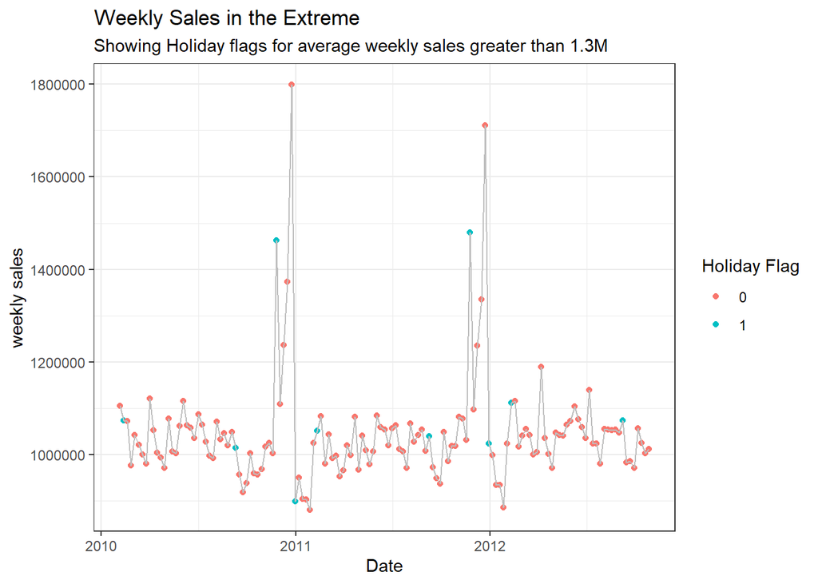

```r
# Line graph showing average weekly sales by date with holiday flags highlighted

ggplot(Mean_wkly_sales, mapping=aes(Date, Weekly_Sales)) +
  geom_point(aes(color=factor(Holiday_Flag)), show.legend=T) +
  geom_line(group=2, color="grey") +
  labs(title="Weekly Sales in the Extreme", subtitle="Showing Holiday flags for average weekly sales greater than 1.3M", y="weekly sales", color='Holiday Flag') +
  theme_bw()
```

#### Correlation Coefficients for all numeric variables

```r
cor(Walmart[, c("Weekly_Sales", "Temperature", "CPI", "Fuel_Price", "Unemployment")])
```

```
##              Weekly_Sales Temperature         CPI   Fuel_Price Unemployment
## Weekly_Sales  1.000000000 -0.06381001 -0.07263416  0.009463786  -0.10617609
## Temperature  -0.063810013  1.00000000  0.17688768  0.144981806   0.10115786
## CPI          -0.072634162  0.17688768  1.00000000 -0.170641795  -0.30202006
## Fuel_Price    0.009463786  0.14498181 -0.17064180  1.000000000  -0.03468374
## Unemployment -0.106176090  0.10115786 -0.30202006 -0.034683745   1.00000000
```

#———————————– Regression Section ——————————————-# ####################################################################################################

## Regression on average weekly sales across all Walmarts

#### General Linear Regression

```r
# fitting a general linear regression model

summary(fitted.model<-glm(Weekly_Sales ~ Store + Holiday_Flag + Temperature + Fuel_Price + CPI + Unemployment, data=Walmart, family=gaussian(link=identity)))
```

```
##
## Call:
## glm(formula = Weekly_Sales ~ Store + Holiday_Flag + Temperature +
##     Fuel_Price + CPI + Unemployment, family = gaussian(link = identity),
##     data = Walmart)
##
## Deviance Residuals:
##     Min       1Q   Median       3Q      Max
## -524476   -69788   -11479    39616  1847116
##
## Coefficients:
##                Estimate Std. Error t value Pr(>|t|)
## (Intercept)   1277907.3   227743.8   5.611 2.09e-08 ***
## Store2         371741.6    18941.9  19.625  < 2e-16 ***
## Store3       -1169648.2    19208.1 -60.894  < 2e-16 ***
## Store4         753446.5    95409.2   7.897 3.34e-15 ***
## Store5       -1267545.3    19697.2 -64.352  < 2e-16 ***
## Store6         -16485.9    19334.0  -0.853 0.393865
## Store7        -920154.1    29070.6 -31.652  < 2e-16 ***
## Store8        -695559.2    19857.9 -35.027  < 2e-16 ***
## Store9       -1056311.8    19840.7 -53.240  < 2e-16 ***
## Store10        635211.2    92451.1   6.871 6.99e-12 ***
## Store11       -215097.0    19211.6 -11.196  < 2e-16 ***
## Store12       -148802.7    86816.5  -1.714 0.086579 .
## Store13        681382.3    93654.9   7.275 3.87e-13 ***
## Store14        575612.8    35531.0  16.200  < 2e-16 ***
## Store15       -684867.1    86667.4  -7.902 3.20e-15 ***
## Store16      -1014451.5    32061.5 -31.641  < 2e-16 ***
## Store17       -444915.5    94572.0  -4.705 2.60e-06 ***
## Store18       -208908.1    84666.6  -2.467 0.013635 *
## Store19        137204.0    86665.1   1.583 0.113436
## Store20        564921.9    20874.9  27.062  < 2e-16 ***
## Store21       -797414.4    18942.0 -42.098  < 2e-16 ***
## Store22       -292623.7    81976.0  -3.570 0.000360 ***
## Store23          1613.0    92435.1   0.017 0.986078
## Store24         60534.1    85908.4   0.705 0.481063
## Store25       -838795.6    20920.4 -40.095  < 2e-16 ***
## Store26       -320520.8    86318.6  -3.713 0.000206 ***
## Store27        460231.8    82690.5   5.566 2.72e-08 ***
## Store28        165717.9    86816.5   1.909 0.056329 .
```

[output cut: 17 more lines]

```
## Holiday_Flag    69239.3     7982.5   8.674  < 2e-16 ***
## Temperature      -833.7      131.7  -6.328 2.65e-10 ***
## Fuel_Price     -41354.2     7161.9  -5.774 8.09e-09 ***
## CPI              2933.4     1033.3   2.839 0.004543 **
## Unemployment   -22467.0     4290.9  -5.236 1.69e-07 ***
## ---
## Signif. codes:  0 '***' 0.001 '**' 0.01 '*' 0.05 '.' 0.1 ' ' 1
##
## (Dispersion parameter for gaussian family taken to be 25645447391)
##
##     Null deviance: 2.0493e+15  on 6434  degrees of freedom
## Residual deviance: 1.6375e+14  on 6385  degrees of freedom
## AIC: 172545
##
## Number of Fisher Scoring iterations: 2
```

not a good model since the response is not normally distributed. We will use a box-cox power transformation

#### Box-Cox Power Transformation

```r
mean_all = Walmart %>%
  group_by(Date) %>%
  summarize(Weekly_Sales = mean(Weekly_Sales),
            Temperature= mean(Temperature),
            CPI= mean(CPI),
            Fuel_Price= mean(Fuel_Price),
            Unemployment=mean(Unemployment))
mean_all
```

```
## # A tibble: 143 × 6
##    Date       Weekly_Sales Temperature   CPI Fuel_Price Unemployment
##    <date>            <dbl>       <dbl> <dbl>      <dbl>        <dbl>
##  1 2010-02-05     1105572.        34.0  168.       2.72         8.62
##  2 2010-02-12     1074148.        34.2  168.       2.69         8.62
##  3 2010-02-19     1072822.        37.7  168.       2.67         8.62
##  4 2010-02-26      977079.        39.2  168.       2.68         8.62
##  5 2010-03-05     1041588.        42.9  168.       2.73         8.62
##  6 2010-03-12     1020564.        47.4  168.       2.77         8.62
##  7 2010-03-19      999755.        50.0  168.       2.82         8.62
##  8 2010-03-26      980755.        48.5  168.       2.82         8.62
##  9 2010-04-02     1120530.        53.1  168.       2.83         8.50
## 10 2010-04-09     1052562.        58.4  168.       2.85         8.50
## # … with 133 more rows
```

```r
shapiro.test(head(Walmart$Weekly_Sales, 400))
```

```
##
##  Shapiro-Wilk normality test
##
## data:  head(Walmart$Weekly_Sales, 400)
## W = 0.84016, p-value < 2.2e-16
```

```r
# fitting box-cox transformation
boxcox_fit<-boxcox(Weekly_Sales ~ Temperature + CPI + Fuel_Price + Unemployment,
                             data=Walmart, lambda=seq(-2,2,1/4), interp=FALSE)
```

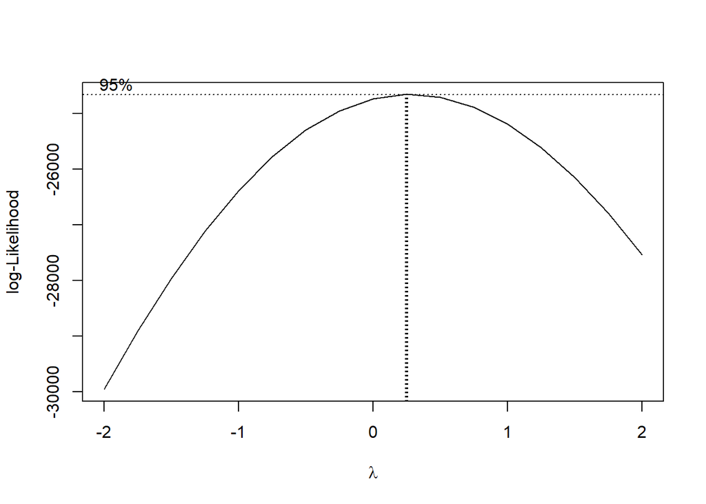

```r
boxcox.data = data.frame(boxcox_fit$x, boxcox_fit$y)
```

```r
ordered.data<- boxcox.data[with(boxcox.data, order(-boxcox_fit.y)),]
ordered.data[1,]
```

```
##    boxcox_fit.x boxcox_fit.y
## 10         0.25    -24650.51
```

```r
wkly_sales= Walmart$Weekly_Sales
tr_wkly_sales = log(Walmart$Weekly_Sales)
head(tr_wkly_sales)
```

```
## [1] 14.31245 14.31140 14.29297 14.15891 14.25686 14.17984
```

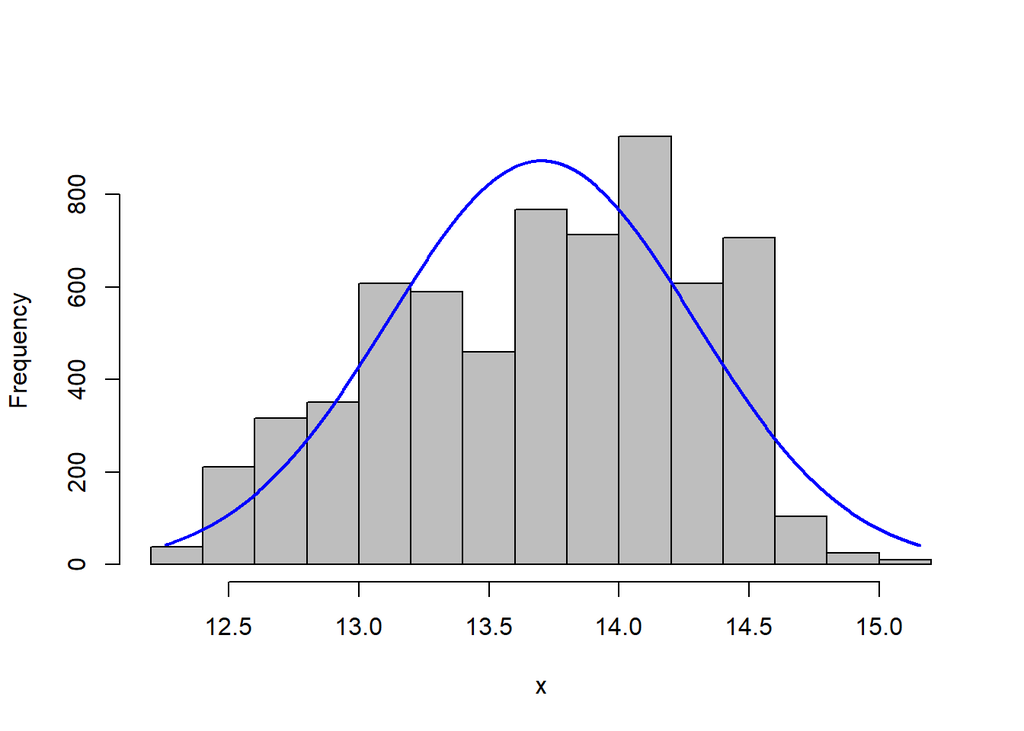

```r
plotNormalHistogram(tr_wkly_sales)
```

```r
shapiro.test(head(tr_wkly_sales, 450))
```

```
##
##  Shapiro-Wilk normality test
##
## data:  head(tr_wkly_sales, 450)
## W = 0.75361, p-value < 2.2e-16
```

Box-Cox Power transformation is not a good fit. Trying Gamma model next for right-skewed distributions.

#### Gamma Regression

```r
# setting reference level for holiday_flag and Store
Store_ = relevel(factor(Walmart$Store), ref=5)
Holiday_Flag_ = relevel(factor(Walmart$Holiday_Flag), ref="0")
```

```r
# fitting Gamma regression model
summary(fitted.model<-glm(Weekly_Sales ~ Store_ + Holiday_Flag_ + Temperature + Fuel_Price + CPI + Unemployment, data=Walmart, family=Gamma(link=log)))
```

```
##
## Call:
## glm(formula = Weekly_Sales ~ Store_ + Holiday_Flag_ + Temperature +
##     Fuel_Price + CPI + Unemployment, family = Gamma(link = log),
##     data = Walmart)
##
## Deviance Residuals:
##      Min        1Q    Median        3Q       Max
## -0.60461  -0.07300  -0.01585   0.04151   0.88677
##
## Coefficients:
##                  Estimate Std. Error t value Pr(>|t|)
## (Intercept)    12.4665471  0.1878016  66.381  < 2e-16 ***
## Store_1         1.6147790  0.0164344  98.256  < 2e-16 ***
## Store_2         1.8292476  0.0164215 111.394  < 2e-16 ***
## Store_3         0.2489056  0.0165031  15.082  < 2e-16 ***
## Store_4         2.0650265  0.0779140  26.504  < 2e-16 ***
## Store_6         1.5981764  0.0158899 100.578  < 2e-16 ***
## Store_7         0.6633455  0.0241008  27.524  < 2e-16 ***
## Store_8         1.0356718  0.0159795  64.812  < 2e-16 ***
## Store_9         0.5254340  0.0159865  32.867  < 2e-16 ***
## Store_10        2.0336192  0.0759259  26.784  < 2e-16 ***
## Store_11        1.4642615  0.0165055  88.713  < 2e-16 ***
## Store_12        1.4967044  0.0722140  20.726  < 2e-16 ***
## Store_13        2.0392673  0.0766416  26.608  < 2e-16 ***
## Store_14        1.9623525  0.0292470  67.096  < 2e-16 ***
## Store_15        0.8858094  0.0710577  12.466  < 2e-16 ***
## Store_16        0.5305089  0.0253034  20.966  < 2e-16 ***
## Store_17        1.2187928  0.0773280  15.761  < 2e-16 ***
## Store_18        1.4534106  0.0695423  20.900  < 2e-16 ***
## Store_19        1.7271599  0.0710557  24.307  < 2e-16 ***
## Store_20        1.9275095  0.0173136 111.329  < 2e-16 ***
## Store_21        0.8952609  0.0164213  54.518  < 2e-16 ***
## Store_22        1.3774707  0.0671546  20.512  < 2e-16 ***
## Store_23        1.6175740  0.0752589  21.493  < 2e-16 ***
## Store_24        1.6746369  0.0705159  23.748  < 2e-16 ***
## Store_25        0.8331688  0.0173529  48.013  < 2e-16 ***
## Store_26        1.3503310  0.0707234  19.093  < 2e-16 ***
## Store_27        1.9278665  0.0677565  28.453  < 2e-16 ***
## Store_28        1.7683631  0.0722140  24.488  < 2e-16 ***
```

[output cut: 17 more lines]

```
## Holiday_Flag_1  0.0623062  0.0066602   9.355  < 2e-16 ***
## Temperature    -0.0006051  0.0001099  -5.504 3.85e-08 ***
## Fuel_Price     -0.0325225  0.0059755  -5.443 5.45e-08 ***
## CPI             0.0021788  0.0008621   2.527   0.0115 *
## Unemployment   -0.0201623  0.0035801  -5.632 1.86e-08 ***
## ---
## Signif. codes:  0 '***' 0.001 '**' 0.01 '*' 0.05 '.' 0.1 ' ' 1
##
## (Dispersion parameter for Gamma family taken to be 0.01785296)
##
##     Null deviance: 2052.732  on 6434  degrees of freedom
## Residual deviance:   98.648  on 6385  degrees of freedom
## AIC: 167839
##
## Number of Fisher Scoring iterations: 4
```

```r
# fitting null model to perform deviance test
null.model<- glm(Weekly_Sales ~ 1, data=Walmart, family=Gamma(link=log))


# deviance test
print(deviance<- -2*(logLik(null.model)-logLik(fitted.model)))
```

```
## 'log Lik.' 19857.16 (df=2)
```

```r
# p value of deviance test
# if p value> .05, null model is better fit. If p value< .05, fitted model is better fit.
p.value<-pchisq(deviance, df=50, lower.tail=FALSE)
p.value
```

```
## 'log Lik.' 0 (df=2)
```

```r
sample_n(Walmart, 1)
```

```
## # A tibble: 1 × 8
##   Store Date       Weekly_Sales Holiday_Flag Temperature Fuel_Pr…¹   CPI Unemp…²
##   <fct> <date>            <dbl>        <dbl>       <dbl>     <dbl> <dbl>   <dbl>
## 1 15    2010-11-05      612988.            0        40.3      3.05  133.    8.07
## # … with abbreviated variable names ¹Fuel_Price, ²Unemployment
```

```r
print(predict(fitted.model, data.frame(Store_="20", Holiday_Flag_="0", Temperature=50.52, Fuel_Price=2.917, CPI=205.0628, Unemployment=7.484), type="response"))
```

```
##       1
## 2114918
```

```r
sample_n(Walmart, 1)
```

```
## # A tibble: 1 × 8
##   Store Date       Weekly_Sales Holiday_Flag Temperature Fuel_Pr…¹   CPI Unemp…²
##   <fct> <date>            <dbl>        <dbl>       <dbl>     <dbl> <dbl>   <dbl>
## 1 18    2011-07-15      974916.            0        74.4      3.83  136.    8.89
## # … with abbreviated variable names ¹Fuel_Price, ²Unemployment
```

```r
print(predict(fitted.model, data.frame(Store_="1", Holiday_Flag_="0", Temperature=86.83, Fuel_Price=3.682, CPI=215.4834, Unemployment=7.962), type="response"))
```

```
##       1
## 1495565
```

Analysis

```r
# Changing Holiday flag to 1 during holiday times where holiday weeks are considered 0
x = Walmart %>%
  filter((Date=="2010-12-10" | Date=="2010-12-17" | Date=="2010-12-24" | Date=="2011-12-09" | Date=="2011-12-16" | Date=="2011-12-23") & Holiday_Flag==0) %>%
  mutate(Holiday_Flag = replace(Holiday_Flag, Holiday_Flag==0, 1))
x
```

```
## # A tibble: 270 × 8
##    Store Date       Weekly_Sales Holiday_Flag Temperature Fuel_P…¹   CPI Unemp…²
##    <fct> <date>            <dbl>        <dbl>       <dbl>    <dbl> <dbl>   <dbl>
##  1 1     2010-12-10     1682614.            1        46.3     2.84  211.    7.84
##  2 1     2010-12-17     1891035.            1        49.8     2.87  211.    7.84
##  3 1     2010-12-24     2387950.            1        52.3     2.89  211.    7.84
##  4 1     2011-12-09     1799682.            1        43.9     3.16  219.    7.87
##  5 1     2011-12-16     1881177.            1        51.6     3.16  219.    7.87
##  6 1     2011-12-23     2270189.            1        48.0     3.11  219.    7.87
##  7 2     2010-12-10     2378727.            1        45.5     2.84  211.    8.16
##  8 2     2010-12-17     2609167.            1        47.6     2.87  211.    8.16
##  9 2     2010-12-24     3436008.            1        50.0     2.89  211.    8.16
## 10 2     2011-12-09     2290549.            1        41.8     3.16  219.    7.44
## # … with 260 more rows, and abbreviated variable names ¹Fuel_Price,
## #   ²Unemployment
```

```r
# modifying Walmart data to delete rows with Holiday weeks that are not flagged
rem_hol = subset(Walmart, (Date!="2010-12-10" & Date!="2010-12-17" & Date!="2010-12-24" & Date!="2011-12-09" &
                     Date!="2011-12-16" & Date!="2011-12-23"))
rem_hol %>%
  filter(Date=="2011-12-09")
```

```
## # A tibble: 0 × 8
## # … with 8 variables: Store <fct>, Date <date>, Weekly_Sales <dbl>,
## #   Holiday_Flag <dbl>, Temperature <dbl>, Fuel_Price <dbl>, CPI <dbl>,
## #   Unemployment <dbl>
```

```r
# appending new holiday weeks to modified Walmart data
Walmart_new= rbind(x, rem_hol)
Walmart_new %>%
  filter(Date=="2010-12-10")
```

```
## # A tibble: 45 × 8
##    Store Date       Weekly_Sales Holiday_Flag Temperature Fuel_P…¹   CPI Unemp…²
##    <fct> <date>            <dbl>        <dbl>       <dbl>    <dbl> <dbl>   <dbl>
##  1 1     2010-12-10     1682614.            1        46.3     2.84  211.    7.84
##  2 2     2010-12-10     2378727.            1        45.5     2.84  211.    8.16
##  3 3     2010-12-10      467642.            1        51.1     2.84  215.    7.56
##  4 4     2010-12-10     2302505.            1        42.4     2.86  127.    7.13
##  5 5     2010-12-10      352812.            1        48.3     2.84  212.    6.77
##  6 6     2010-12-10     1834738.            1        48.5     2.84  213.    7.01
##  7 7     2010-12-10      599730.            1        24.2     2.73  191.    9.14
##  8 8     2010-12-10     1069062.            1        42.5     2.84  215.    6.43
##  9 9     2010-12-10      618122.            1        46.1     2.84  215.    6.56
## 10 10    2010-12-10     2411790.            1        60.5     3.09  127.    9.00
## # … with 35 more rows, and abbreviated variable names ¹Fuel_Price,
## #   ²Unemployment
```

```r
# calculating mean of each sales week using new Holiday flags
Walmart_new_mean= Walmart_new %>%
  group_by(Date, Holiday_Flag) %>%
  summarise(Weekly_Sales = mean(Weekly_Sales, na.rm=TRUE))
Walmart_new_mean
```

```
## # A tibble: 143 × 3
## # Groups:   Date [143]
##    Date       Holiday_Flag Weekly_Sales
##    <date>            <dbl>        <dbl>
##  1 2010-02-05            0     1105572.
##  2 2010-02-12            1     1074148.
##  3 2010-02-19            0     1072822.
##  4 2010-02-26            0      977079.
##  5 2010-03-05            0     1041588.
##  6 2010-03-12            0     1020564.
##  7 2010-03-19            0      999755.
##  8 2010-03-26            0      980755.
##  9 2010-04-02            0     1120530.
## 10 2010-04-09            0     1052562.
## # … with 133 more rows
```

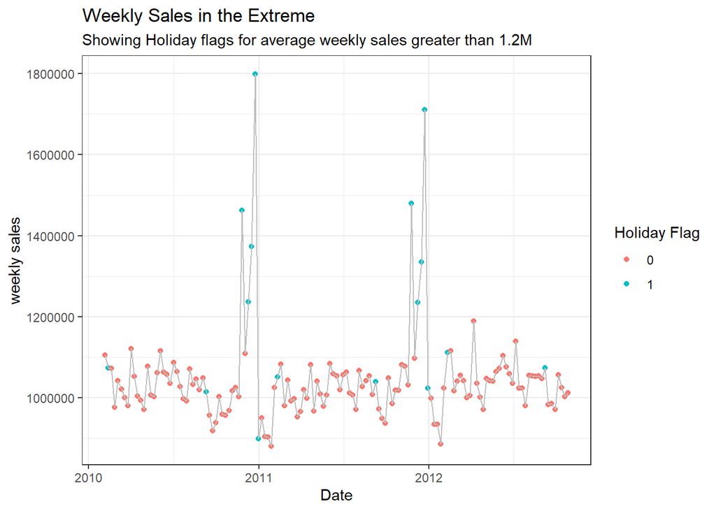

```r
# Line graph showing average weekly sales by date with new holiday flags highlighted

ggplot(Walmart_new_mean, mapping=aes(Date, Weekly_Sales)) +
  geom_point(aes(color=factor(Holiday_Flag)), show.legend=T) +
  geom_line(group=2, color="grey") +
  labs(title="Weekly Sales in the Extreme", subtitle="Showing Holiday flags for average weekly sales greater than 1.2M", y="weekly sales", color='Holiday Flag') +
  theme_bw()
```

We now see that all extremes over 1.2M are during the holiday times. Specifically, from thanksgiving week to Christmas.

#### Separating outlier weeks

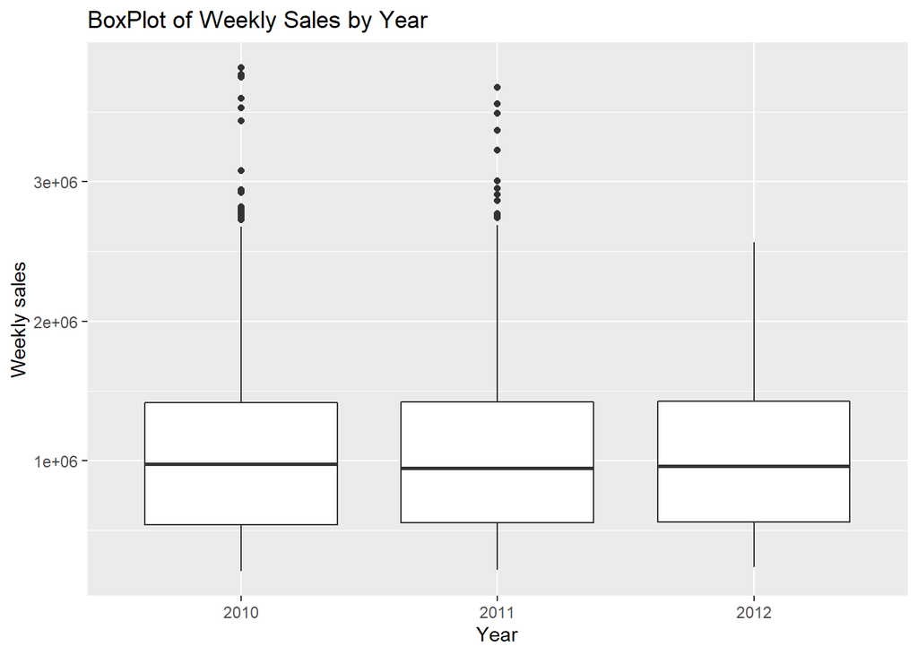

```r
Walmart_year = Walmart |>
  separate(Date, c("Year", "Month", "Day"), sep = "-", remove = FALSE) |>
  transform(Year = as.factor(Year), Month = as.factor(Month), Day = as.factor(Day))

ggplot(Walmart_year, aes(x=Year, y=Weekly_Sales))+
  geom_boxplot() +
  labs(title = 'BoxPlot of Weekly Sales by Year', y='Weekly sales', x='Year')
```

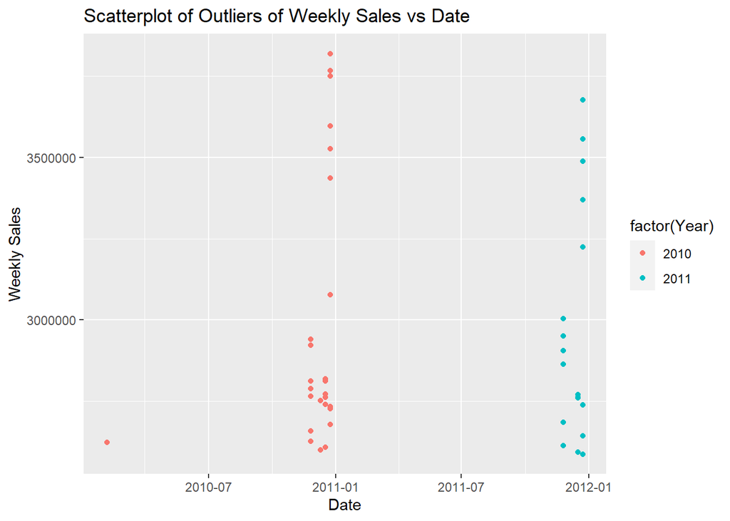

```r
#finding and saving the highest weekly sale in 2012 to differentiate outliers in 2010 and 2011
Walmart_year2012 = Walmart_year |>
  group_by(Year, Weekly_Sales) |>
  filter(Year == 2012)
max2012 = max(Walmart_year2012$Weekly_Sales)

new_extremes = Walmart_year |>
  filter(Weekly_Sales > max2012)

#most of the high sales are from thanksgiving weeks to xmas weeks
ggplot(data=new_extremes, mapping=aes(x=Date,y=Weekly_Sales, color=factor(Year))) +
  geom_point() +
  labs(title="Scatterplot of Outliers of Weekly Sales vs Date", y="Weekly Sales")
```

### Separating the date

##### BoxPlot of Weekly Sales by Year

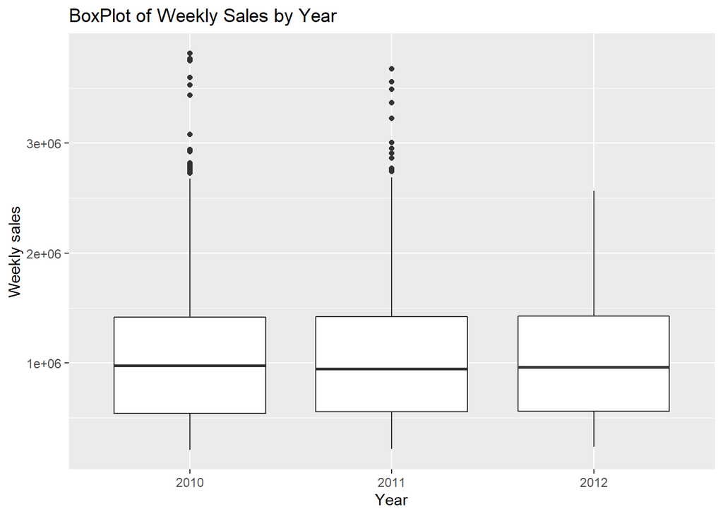

```r
#looking at data by year
Walmart_year = Walmart |>
  separate(Date, c("Year", "Month", "Day"), sep = "-", remove = FALSE) |>
  transform(Year = as.factor(Year), Month = as.factor(Month), Day = as.factor(Day))

ggplot(Walmart_year, aes(x=Year, y=Weekly_Sales))+
  geom_boxplot() +
  labs(title = 'BoxPlot of Weekly Sales by Year', y='Weekly sales', x='Year')
```

### Bootstrapping

```r
#grouping by month to get the mean sales by month
Walmart_month = Walmart_year |>
  dplyr:::select(Month, Weekly_Sales) |>
  group_by(Month) |>
  summarize(mean_sales = mean(Weekly_Sales))

#bootstrapping sales each month with 50 reps
virtual_resampled_means <- Walmart_month |>
  rep_sample_n(size = 12, replace = TRUE, reps = 50) |>
  group_by(replicate) |>
  summarize(mean = mean(mean_sales))
```

[output not shown]

```r
ggplot(virtual_resampled_means, aes(x = mean)) +
  geom_histogram(binwidth = 10000, color = "white", boundary = 1300000) +
  labs(x = "sample mean sales",
       title = "Bootstrap distribution of the sample mean")
```

[output not shown]

```r
#bootstrapping sales each month with 100 reps
virtual_resampled_means <- Walmart_month |>
  rep_sample_n(size = 12, replace = TRUE, reps = 100) |>
  group_by(replicate) |>
  summarize(mean = mean(mean_sales))
```

[output not shown]

```r
ggplot(virtual_resampled_means, aes(x = mean)) +
  geom_histogram(binwidth = 10000, color = "white", boundary = 1300000) +
  labs(x = "sample mean sales",
       title = "Bootstrap distribution of the sample mean")
```

[output not shown]

```r
#bootstrapping with 1000 reps
virtual_resampled_means3 <- Walmart_month |>
  rep_sample_n(size = 12, replace = TRUE, reps = 1000) |>
  group_by(replicate) |>
  summarize(mean = mean(mean_sales))
```

[output not shown]

```r
ggplot(virtual_resampled_means3, aes(x = mean)) +
  geom_histogram(binwidth = 10000, color = "white", boundary = 1300000) +
  labs(x = "sample mean sales",
       title = "Bootstrap distribution of the sample mean")
```

[output not shown]

From above: Mean: $1,046,965 Median: $960,746

```r
#confidence interval using the percentile method
quantile(virtual_resampled_means3$mean, c(0.025, 0.975))
```

[output not shown]

```r
#visual of the confidence interval
ggplot(virtual_resampled_means3, aes(x = mean)) +
  geom_histogram(binwidth = 10000, color = "white", boundary = 1300000) +
  geom_vline(xintercept = c(1005037, 1098265), color = "blue") +
  labs(x = "sample mean sales",
       title = "Bootstrap distribution of the sample mean",
       subtitle = "Percentile method confidence interval")
```

[output not shown]

```r
#confidence interval using the standard error method
#middle 95% of values of bootstrap distribution
virtual_resampled_means3 |>
  summarize(SE = sd(mean))
```

[output not shown]

```r
#visual of the confidence interval
ggplot(virtual_resampled_means3, aes(x = mean)) +
  geom_histogram(binwidth = 10000, color = "white", boundary = 1300000) +
  geom_vline(xintercept = c(998285.97, 1095644.03), color = "blue") +
  labs(x = "sample mean sales",
       title = "Bootstrap distribution of the sample mean",
       subtitle = "Standard error confidence interval")
```

[output not shown]

```r
#visual of both confidence intervals
ggplot(virtual_resampled_means3, aes(x = mean)) +
  geom_histogram(binwidth = 10000, color = "white", boundary = 1300000) +
  geom_vline(xintercept = c(1005037, 1098265), color = "blue") +
  geom_vline(xintercept = c(998285.97, 1095644.03), color = "red") +
  labs(x = "sample mean sales",
       title = "Bootstrap distribution of the sample mean",
       subtitle = "blue = percentile method, red = standard error method")
```

[output not shown]

other data explorations

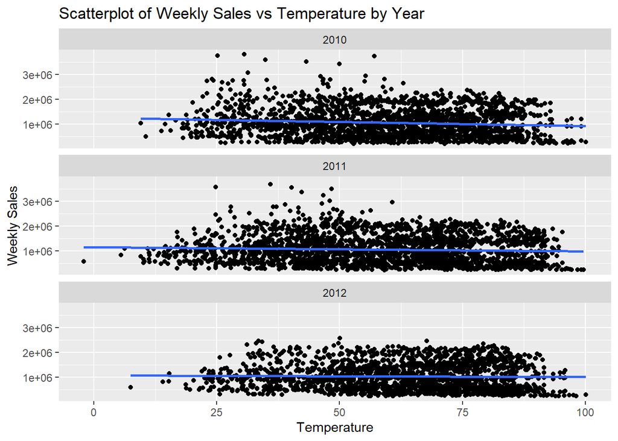

```r
ggplot(data = Walmart_year, mapping = aes(x = Temperature, y = Weekly_Sales)) +
  geom_point() +
  geom_smooth(method = lm, formula = y ~ x, se = FALSE) +
  facet_wrap(~ Year, ncol = 1) +
  labs(title="Scatterplot of Weekly Sales vs Temperature by Year", y = "Weekly Sales")
```

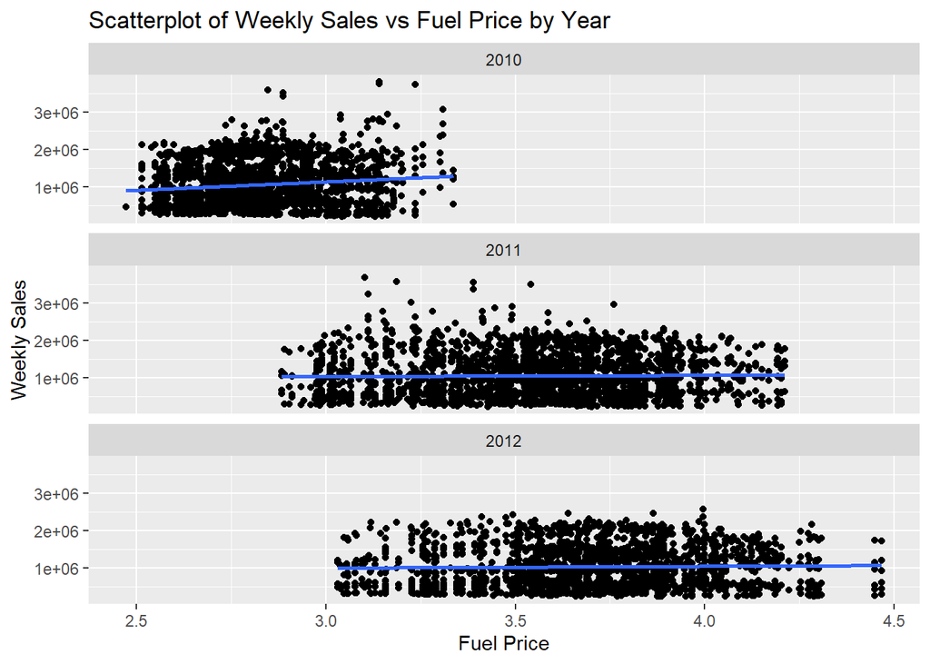

```r
ggplot(data = Walmart_year, mapping = aes(x = Fuel_Price, y = Weekly_Sales)) +
  geom_point() +
  geom_smooth(method = lm, formula = y ~ x, se = F) +
  facet_wrap(~ Year, ncol = 1) +
  labs(title="Scatterplot of Weekly Sales vs Fuel Price by Year", x = "Fuel Price", y = "Weekly Sales")
```